# Assignment-5

VenkataSaiReddy

2025-03-21

```r
#install.packages("tidyverse")
#install.packages("factoextra")
#install.packages("caret")
#install.packages("e1071")
#install.packages("cluster")
#install.packages("dbscan")
#install.packages("fpc")
```

```r
library(tidyverse)
library(factoextra)
library(caret)
library(e1071)
library(cluster)
library(dbscan)
library(fpc)
```

# Q1-A Explain how normalization and the number of clusters (k) can affect the clustering outcome?

## Normalization and its impact on clustering:

**Definition:** Normalization (or feature scaling) is the conversion of numerical attributes to a common scale, usually [0, 1] or zero mean unit variance (standardization).

Scaling facilitates the standardization of the range and distribution of the features on a given data set. Scaling is applied to ensure all the features are treated equally when being analyzed, especially in cases where the features have differing units or ranges. This is important for distance based models, such as clustering or machine learning models which have Euclidean distance as a measurement.

## Impact on K-Means:

K-Means uses Euclidean distance for assigning points to clusters. Unless features are normalized, those with greater numerical value ranges will dominate the distance calculation and may predominate in the algorithm even if in real life, they are unimportant.

For example, if one feature is between 1 and 1000 and another between 0 and 1, the algorithm would overemphasize the first feature.

It may result in biased clustering where clusters are formed based on scale and not on meaningful structure.

Correct normalization enables every feature to contribute equally towards distance calculation, leading to meaningful and precise clusters.

## Value of k (number of clusters) and how it affects clustering:

Choice of k is a significant decision in K-Means and directly affects clustering results.

### Too small k:

**Leads to underfitting:** distinct groups may be lumped into one cluster. The model may not be able to capture important substructures in data.

### Too big k:

**Leads to overfitting:** data points can be grouped into redundant clusters. Can create artificial splits in the data which do not relate to real patterns. Impact on performance:

K-Means attempts to minimize intra-cluster variance (within-cluster distance). Increasing k decreases the overall variance but too large a k can make interpretability and generalization suffer.

## Common methods to select k:

**Elbow method:** Graph the within-cluster sum of squares (WCSS) against k. The “elbow” point indicates an optimal value for k.

**Silhouette score:** Approximates how close a point is to its own cluster versus other clusters. The higher the value, the better the clustering.

## In-short:

Normalization ensures fair contribution of all features to the distance metric, improving cluster quality.

The granularity and interpretability of the results are greatly impacted by the number of clusters (k), which needs to be carefully selected to strike a balance between underfitting and overfitting.

# Q1-B K-Means Clustering on the Wine Dataset

```r
# Load necessary libraries
library(factoextra)

# Load the wine dataset
wine_data <- read.csv("C:/R Assignments/wine-clustering.csv")

str(wine_data)  # Checking structure of the  dataset
```

```
## 'data.frame':    178 obs. of  13 variables:
##  $ Alcohol             : num  14.2 13.2 13.2 14.4 13.2 ...
##  $ Malic_Acid          : num  1.71 1.78 2.36 1.95 2.59 1.76 1.87 2.15 1.64 1.35 ...
##  $ Ash                 : num  2.43 2.14 2.67 2.5 2.87 2.45 2.45 2.61 2.17 2.27 ...
##  $ Ash_Alcanity        : num  15.6 11.2 18.6 16.8 21 15.2 14.6 17.6 14 16 ...
##  $ Magnesium           : int  127 100 101 113 118 112 96 121 97 98 ...
##  $ Total_Phenols       : num  2.8 2.65 2.8 3.85 2.8 3.27 2.5 2.6 2.8 2.98 ...
##  $ Flavanoids          : num  3.06 2.76 3.24 3.49 2.69 3.39 2.52 2.51 2.98 3.15 ...
##  $ Nonflavanoid_Phenols: num  0.28 0.26 0.3 0.24 0.39 0.34 0.3 0.31 0.29 0.22 ...
##  $ Proanthocyanins     : num  2.29 1.28 2.81 2.18 1.82 1.97 1.98 1.25 1.98 1.85 ...
##  $ Color_Intensity     : num  5.64 4.38 5.68 7.8 4.32 6.75 5.25 5.05 5.2 7.22 ...
##  $ Hue                 : num  1.04 1.05 1.03 0.86 1.04 1.05 1.02 1.06 1.08 1.01 ...
##  $ OD280               : num  3.92 3.4 3.17 3.45 2.93 2.85 3.58 3.58 2.85 3.55 ...
##  $ Proline             : int  1065 1050 1185 1480 735 1450 1290 1295 1045 1045 ...
```

# Normalize the Data

```r
# Normalize the dataset
wines.norm <- scale(wine_data)

# Check structure of the scaled dataset
str(wines.norm)
```

```
##  num [1:178, 1:13] 1.514 0.246 0.196 1.687 0.295 ...
##  - attr(*, "dimnames")=List of 2
##   ..$ : NULL
##   ..$ : chr [1:13] "Alcohol" "Malic_Acid" "Ash" "Ash_Alcanity" ...
##  - attr(*, "scaled:center")= Named num [1:13] 13 2.34 2.37 19.49 99.74 ...
##   ..- attr(*, "names")= chr [1:13] "Alcohol" "Malic_Acid" "Ash" "Ash_Alcanity" ...
##  - attr(*, "scaled:scale")= Named num [1:13] 0.812 1.117 0.274 3.34 14.282 ...
##   ..- attr(*, "names")= chr [1:13] "Alcohol" "Malic_Acid" "Ash" "Ash_Alcanity" ...
```

```r
# View the first few rows of normalized data
head(wines.norm)
```

```
##        Alcohol  Malic_Acid        Ash Ash_Alcanity  Magnesium Total_Phenols
## [1,] 1.5143408 -0.56066822  0.2313998   -1.1663032 1.90852151     0.8067217
## [2,] 0.2455968 -0.49800856 -0.8256672   -2.4838405 0.01809398     0.5670481
## [3,] 0.1963252  0.02117152  1.1062139   -0.2679823 0.08810981     0.8067217
## [4,] 1.6867914 -0.34583508  0.4865539   -0.8069748 0.92829983     2.4844372
## [5,] 0.2948684  0.22705328  1.8352256    0.4506745 1.27837900     0.8067217
## [6,] 1.4773871 -0.51591132  0.3043010   -1.2860793 0.85828399     1.5576991
##      Flavanoids Nonflavanoid_Phenols Proanthocyanins Color_Intensity        Hue
## [1,]  1.0319081           -0.6577078       1.2214385       0.2510088  0.3611585
## [2,]  0.7315653           -0.8184106      -0.5431887      -0.2924962  0.4049085
## [3,]  1.2121137           -0.4970050       2.1299594       0.2682629  0.3174085
## [4,]  1.4623994           -0.9791134       1.0292513       1.1827317 -0.4263410
## [5,]  0.6614853            0.2261576       0.4002753      -0.3183774  0.3611585
## [6,]  1.3622851           -0.1755994       0.6623487       0.7298108  0.4049085
##          OD280     Proline
## [1,] 1.8427215  1.01015939
## [2,] 1.1103172  0.96252635
## [3,] 0.7863692  1.39122370
## [4,] 1.1807407  2.32800680
## [5,] 0.4483365 -0.03776747
## [6,] 0.3356589  2.23274072
```

### Interpretation

The dataset has been normalized using scale(), standardizing each variable to have a mean of 0 and standard deviation of 1.

Now, each value represents how many standard deviations a sample is from the mean of that feature. This ensures all variables contribute equally in distance-based analyses like K-Means clustering.

```r
# Check if mean ≈ 0 and sd ≈ 1 for each column
apply(wines.norm, 2, mean)     # Should be close to 0
```

```
##              Alcohol           Malic_Acid                  Ash
##        -8.591766e-16        -6.776446e-17         8.045176e-16
##         Ash_Alcanity            Magnesium        Total_Phenols
##        -7.720494e-17        -4.073935e-17        -1.395560e-17
##           Flavanoids Nonflavanoid_Phenols      Proanthocyanins
##         6.958263e-17        -1.042186e-16        -1.221369e-16
##      Color_Intensity                  Hue                OD280
##         3.649376e-17         2.093741e-16         3.003459e-16
##              Proline
##        -1.034429e-16
```

```r
apply(wines.norm, 2, sd)       # Should be close to 1
```

```
##              Alcohol           Malic_Acid                  Ash
##                    1                    1                    1
##         Ash_Alcanity            Magnesium        Total_Phenols
##                    1                    1                    1
##           Flavanoids Nonflavanoid_Phenols      Proanthocyanins
##                    1                    1                    1
##      Color_Intensity                  Hue                OD280
##                    1                    1                    1
##              Proline
##                    1
```

## Interpretation

This output confirms that the normalization worked correctly. The means of all columns are approximately 0, and the standard deviations are exactly 1.This ensures that all features are on the same scale, making the dataset ready for clustering or other multivariate analyses.

# Determine Optimal Number of Clusters

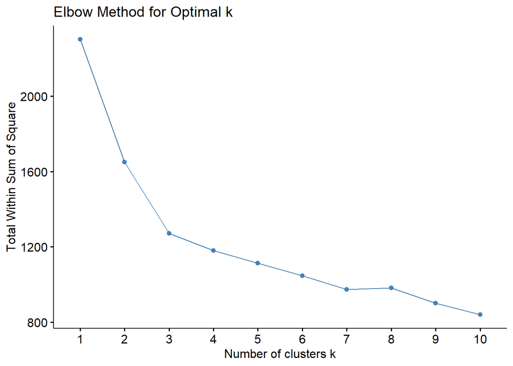

```r
#Finding the optimal number of clusters using the Elbow Methods

fviz_nbclust(wines.norm, kmeans, method = "wss") +
  labs(title = "Elbow Method for Optimal k")
```

### Interpretation

The WSS decreases as the number of clusters (k) increases — this is expected because more clusters usually reduce the within-cluster variation.

A sharp bend (“elbow”) appears at k = 3, after which the rate of decrease slows significantly.

This suggests that 3 is the optimal number of clusters, as adding more clusters beyond this point results in diminishing returns in reducing WSS.

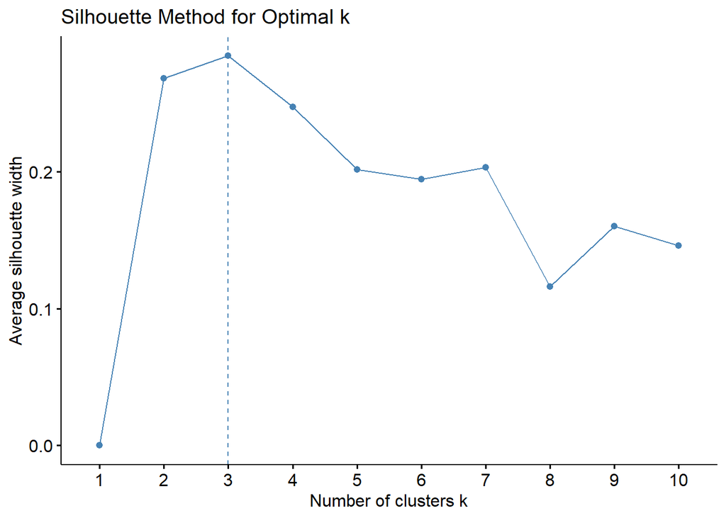

```r
# Silhouette Method

fviz_nbclust(wines.norm, kmeans, method = "silhouette") +
  labs(title = "Silhouette Method for Optimal k")
```

### Interpretation

The average silhouette width peaks at k = 3, meaning clustering is most cohesive and well-separated at 3 clusters.

After k = 3, the silhouette width decreases, indicating that more clusters reduce the quality of separation between groups.

### OverAll

Both methods agree that k = 3 is the most appropriate choice for clustering the wine dataset.

# Apply K-Means Clustering

```r
# Set seed for reproducibility
set.seed(123)

# Check for duplicated rows
sum(duplicated(wines.norm))  # it retuns Number of duplicate rows
```

```
## [1] 0
```

```r
# Apply K-Means with k = 3
kmeans.wines <- kmeans(wines.norm, centers = 3, nstart = 25)

# Displays the coordinates (mean values) of each variable for every cluster center
kmeans.wines$centers
```

```
##      Alcohol Malic_Acid        Ash Ash_Alcanity   Magnesium Total_Phenols
## 1  0.1644436  0.8690954  0.1863726    0.5228924 -0.07526047   -0.97657548
## 2  0.8328826 -0.3029551  0.3636801   -0.6084749  0.57596208    0.88274724
## 3 -0.9234669 -0.3929331 -0.4931257    0.1701220 -0.49032869   -0.07576891
##    Flavanoids Nonflavanoid_Phenols Proanthocyanins Color_Intensity        Hue
## 1 -1.21182921           0.72402116     -0.77751312       0.9388902 -1.1615122
## 2  0.97506900          -0.56050853      0.57865427       0.1705823  0.4726504
## 3  0.02075402          -0.03343924      0.05810161      -0.8993770  0.4605046
##        OD280    Proline
## 1 -1.2887761 -0.4059428
## 2  0.7770551  1.1220202
## 3  0.2700025 -0.7517257
```

### Interpretation

The line **sum(duplicated(wines.norm))** returned 0, indicating that there are no duplicate rows in the normalized dataset. This ensures that the clustering results are not biased or skewed by repeated observations, improving the reliability of the K-Means output.

**Alcohol** Cluster 1 has a modestly positive value (0.16), indicating slightly above-average alcohol levels. Cluster 2 has the highest value (0.83), suggesting wines with notably higher alcohol content. Cluster 3 has a strong negative value (−0.92), indicating these wines have the lowest alcohol levels among the clusters.

**Malic_Acid** Cluster 1 (0.87) shows the highest Malic Acid concentration, indicating greater acidity. Clusters 2 (−0.30) and 3 (−0.39) are both below average, suggesting lower acidity levels.

**Ash** Cluster 2 (0.36) has the highest Ash content. Cluster 1 (0.19) is slightly above average, while Cluster 3 (−0.49) has the lowest Ash concentration.

**Ash_Alkalinity** Cluster 1 (0.52) and Cluster 3 (0.17) have positive values, suggesting more alkaline ash. Cluster 2 (−0.61) shows below-average Ash Alkalinity.

**Magnesium** Cluster 2 (0.58) shows elevated Magnesium levels. Cluster 1 (−0.08) is close to average, while Cluster 3 (−0.49) is significantly lower.

**Total_Phenols** Cluster 2 (0.88) has the richest Total Phenols content, enhancing flavor and structure. Cluster 3 (−0.08) is slightly below average, and Cluster 1 (−0.98) has the lowest phenolic content.

**Flavanoids** Cluster 1 (−1.21) shows the lowest Flavonoid levels, suggesting reduced antioxidant presence. Cluster 2 (0.98) is high in flavonoids, and Cluster 3 (0.02) is approximately average.

**Nonflavanoid_Phenols** Cluster 1 (0.72) has the highest concentration. Clusters 2 (−0.56) and 3 (−0.03) show lower levels, with Cluster 2 being the lowest.

**Proanthocyanins** Cluster 2 (0.58) leads in Proanthocyanins, followed by Cluster 3 (0.06). Cluster 1 (−0.78) is significantly below average, indicating fewer of these antioxidants.

**Color_Intensity** Cluster 1 (0.94) shows the most intense color. Cluster 2 (0.17) is slightly above average, while Cluster 3 (−0.90) is well below average in color intensity.

**Hue** Clusters 2 (0.47) and 3 (0.46) have above-average hue levels. Cluster 1 (−1.16) is substantially lower in hue, indicating a visual difference in tone.

**OD280** Cluster 2 (0.78) shows the highest OD280 (a measure of wine quality and phenolic richness). Cluster 3 (0.27) is above average, and Cluster 1 (−1.29) is far below average.

**Proline** Cluster 2 (1.12) has a high concentration of Proline, an amino acid associated with wine maturity. Cluster 1 (−0.41) is slightly below average, and Cluster 3 (−0.75) is the lowest.

```r
# Shows the number of wine samples (observations) in each cluster
kmeans.wines$size
```

```
## [1] 51 62 65
```

### Interpretation

The wines were grouped into 3 clusters of sizes 51, 62, and 65 by the K-Means algorithm, with Cluster 2 having the most alcohol, flavanoids, and proline, which are potentially suggestive of the higher-quality wines.

#for knowing which wine samples belong to which of the three clusters

```r
# Observations in Cluster 1
cat("Cluster 1 includes wine samples:\n")
```

```
## Cluster 1 includes wine samples:
```

```r
print(which(kmeans.wines$cluster == 1))
```

```
##  [1]  62  84 119 131 132 133 134 135 136 137 138 139 140 141 142 143 144 145 146
## [20] 147 148 149 150 151 152 153 154 155 156 157 158 159 160 161 162 163 164 165
## [39] 166 167 168 169 170 171 172 173 174 175 176 177 178
```

```r
# Observations in Cluster 2
cat("Cluster 2 includes wine samples:\n")
```

```
## Cluster 2 includes wine samples:
```

```r
print(which(kmeans.wines$cluster == 2))
```

```
##  [1]   1   2   3   4   5   6   7   8   9  10  11  12  13  14  15  16  17  18  19
## [20]  20  21  22  23  24  25  26  27  28  29  30  31  32  33  34  35  36  37  38
## [39]  39  40  41  42  43  44  45  46  47  48  49  50  51  52  53  54  55  56  57
## [58]  58  59  74  96 122
```

```r
# Observations in Cluster 3
cat("Cluster 3 includes wine samples:\n")
```

```
## Cluster 3 includes wine samples:
```

```r
print(which(kmeans.wines$cluster == 3))
```

```
##  [1]  60  61  63  64  65  66  67  68  69  70  71  72  73  75  76  77  78  79  80
## [20]  81  82  83  85  86  87  88  89  90  91  92  93  94  95  97  98  99 100 101
## [39] 102 103 104 105 106 107 108 109 110 111 112 113 114 115 116 117 118 120 121
## [58] 123 124 125 126 127 128 129 130
```

# checking which number that belongs to which cluster

```r
kmeans.wines$cluster[c(62, 3, 100)]
```

```
## [1] 1 2 3
```

### Interpretation

The 62 data point in the dataset has been assigned to cluster1. The 3 data point in the dataset has been assigned to cluster2. The 100 data point in the dataset has been assigned to cluster3.

```r
# Shows how compact each cluster is (within-cluster sum of squares)
kmeans.wines$withinss
```

```
## [1] 326.3537 385.6983 558.6971
```

### Interpretation

The Within-cluster sum of squares (withinss) calculates how widely distributed the data points are within each cluster. A lower value implies that the points are closer to the cluster center, resulting in a tighter cluster. Cluster 1 has 326.3537, indicating that it has the tightest and most cohesive cluster. Cluster 2 has 385.6983, suggesting a moderate dispersion of points within this cluster, but Cluster 3 has the highest value of 558.6971, indicating that the points in this cluster are more spread out from the center and is the least cohesive, with points being more dispersed.

# Visualize Clusters

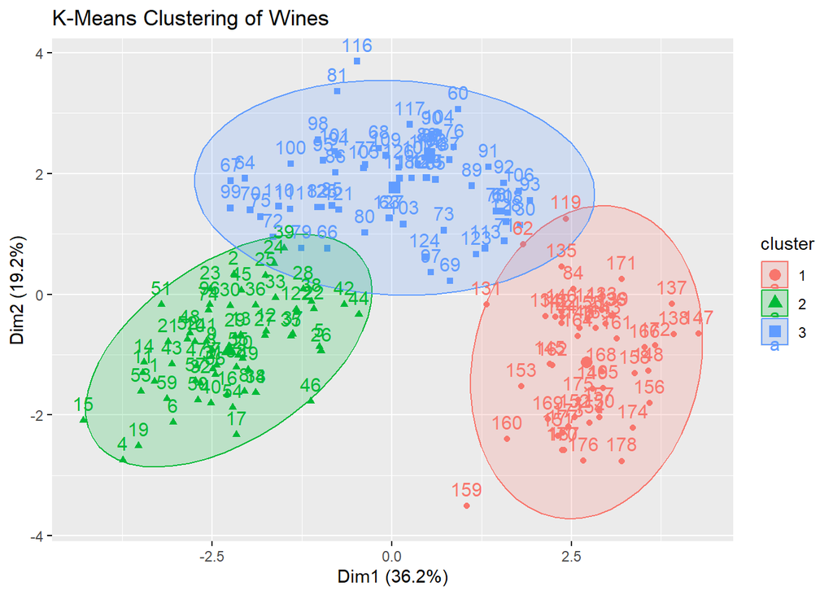

```r
# Visualize the clusters
fviz_cluster(kmeans.wines, data = wines.norm,
             geom = c("point", "text"), ellipse.type = "norm") +
  labs(title = "K-Means Clustering of Wines")
```

### Interpretation

The wine dataset has been grouped into 3 distinct clusters with minimal overlap:

**Cluster 3 (blue squares)** is more centrally located and slightly overlapping, possibly representing wines with moderate characteristics.

The separation along Dim1 (36.2%) and Dim2 (19.2%) suggests that these two dimensions together explain over 55% of the data’s variation, making the clusters visually and statistically meaningful.

### Insights:

K-Means was able to group wines into 3 distinct chemical profiles

These clusters could help wine producers segment their wines by style or quality

Even without class labels, unsupervised learning reveals meaningful structure

Normalization was crucial to ensure all attributes contributed equally to clustering

Overall, K-Means provides an efficient way to uncover hidden patterns in wine characteristics, Aiding classification, marketing, and quality control in winemaking.

# Q2-A DBSCAN vs K-Means - Key Differences

DBSCAN (Density-Based Spatial Clustering of Applications with Noise) and K-Means are both clustering algorithms, but they differ in several key ways:

### Handling of Noise and Outliers

K-Means: Assumes all points belong to a cluster and assigns every point to a group, even if it’s an outlier.

DBSCAN: Can detect noise. Points that don’t fit well into any dense area are labeled as “noise” (outliers) and not assigned to any cluster.

### Cluster Shape

K-Means: Assumes clusters are spherical and of similar size. It performs poorly when clusters have arbitrary shapes or varying densities.

DBSCAN: Can find arbitrarily shaped clusters and works well with non-linear structures.

### Number of Clusters

K-Means: Requires you to pre-define k (number of clusters).

DBSCAN: Does not need k as input. Clusters are formed based on density using epsilon (ε) and minimum Points.

### Sensitivity

K-Means: Sensitive to initial centroids and scaling.

DBSCAN: Sensitive to ε(neighborhood size) and minimum Points (minimum points to form a dense region).

### Data Distribution Assumptions

K-Means: Assumes clusters are convex and isotropic (spherical in shape).

DBSCAN: Makes no assumptions about the cluster shape or distribution, making it more flexible for real-world data.

### Handling Varying Densities

K-Means: Struggles with datasets where clusters have different densities — it may split a dense cluster or merge sparse ones.

DBSCAN: Performs well with clusters of varying densities (if parameters ε and MinPts are well chosen).

### Input Requirements

K-Means: Requires only the number of clusters k.

DBSCAN: Requires ε (epsilon) and MinPts, which may be harder to choose without prior knowledge.

### Stability of Results

K-Means: Results can vary with different initial centroids — often requires multiple runs with different seeds (nstart parameter).

DBSCAN: More deterministic — given the same parameters, DBSCAN always gives the same output.

### Dimensionality Suitability

K-Means: Performs better in low to moderately high-dimensional data.

DBSCAN: Struggles in high-dimensional spaces due to the “curse of dimensionality” — distance-based density becomes less meaningful.

### Use Cases / Application Areas

K-Means: Well-suited for market segmentation, image compression, and customer clustering when clusters are spherical and of equal size.

DBSCAN: Great for spatial data, anomaly detection, and datasets with noise or irregular cluster shapes (e.g., geographical data, GPS paths).

# Question 2-B #Assume k=3, apply DBSCAN to the wine dataset, and analyze the clusters formed. How do the parameters epsilon (ε) and minPts influence the clustering results

# Load Required Libraries

```r
library(dbscan)
library(fpc)
library(factoextra)
```

# Load and Normalize Dataset

```r
# Load the wine dataset (update the path if needed)
wine_data <- read.csv("C:/R Assignments/wine-clustering.csv")

# Normalize the dataset to ensure all features contribute equally
wine_scaled <- scale(wine_data)
```

# Estimate Epsilon (ε) with k-Nearest Neighbor Distance Plot

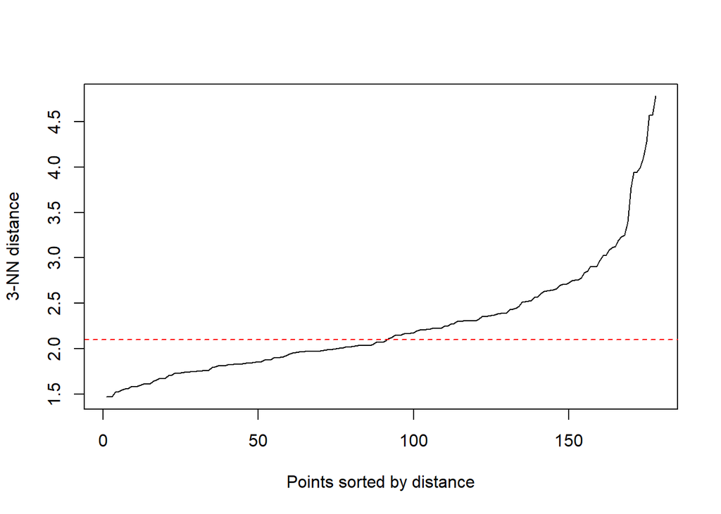

```r
# Using k = 3 to find optimal epsilon visually

kNNdistplot(wine_scaled, k = 3)
abline(h = 2.1, lty = 2, col = "red")  # Adjust based on the elbow
```

# Apply DBSCAN with Chosen Parameters

```r
# Apply DBSCAN on the full scaled dataset

set.seed(123)

db_result <- dbscan::dbscan(wine_scaled, eps = 2.1, minPts = 5)

# Display clustering summary
print(db_result)
```

```
## DBSCAN clustering for 178 objects.
## Parameters: eps = 2.1, minPts = 5
## Using euclidean distances and borderpoints = TRUE
## The clustering contains 3 cluster(s) and 61 noise points.
##
##  0  1  2  3
## 61 83 13 21
##
## Available fields: cluster, eps, minPts, metric, borderPoints
```

```r
table(Cluster = db_result$cluster)
```

```
## Cluster
##  0  1  2  3
## 61 83 13 21
```

## Interpretation

DBSCAN was applied to all 13 normalized features using ε = 2.1 and minPts = 5. These values were selected based on the kNN distance plot, aiming to capture dense clusters while identifying noise.

After identifying three clusters, the program categorized 61 points as noise (cluster 0). Cluster 2 has 13 points, Cluster 3 has 21 points, and Cluster 1 is the largest cluster with 83 points. Points that are probably outliers and don’t fit into any dense group are known as noise points.

This result suggests that the dataset has meaningful groupings, but also a significant number of outliers. The high number of noise points (about 34% of the data) indicates that the ε value might be a bit strict — but it also shows DBSCAN’s strength in identifying less obvious structure and excluding scattered points.

# Visualize Clustering with Total_Phenols & Color_Intensity

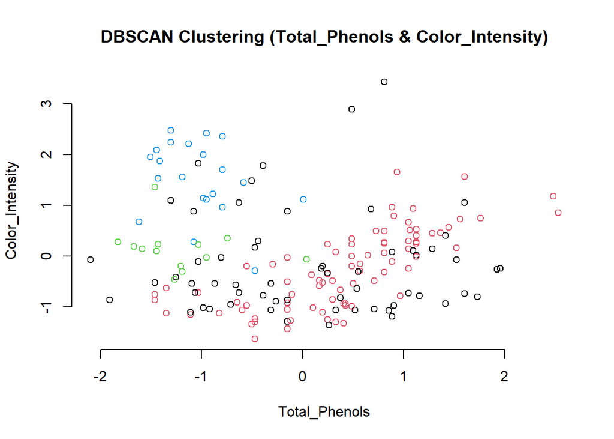

```r
# Plot using features 6 (Total_Phenols) and 10 (Color_Intensity)
plot(db_result, wine_scaled[, c(6, 10)],
     main = "DBSCAN Clustering (Total_Phenols & Color_Intensity)",
     frame = FALSE)
```

## Interpretation

The plot shows how DBSCAN grouped the data based on Total_Phenols and Color_Intensity. Points with similar values in these two features are grouped into the same cluster, while dissimilar or isolated points are treated as noise.

There are three main color-coded clusters, which match the DBSCAN result (Clusters 1, 2, and 3). Each color represents a group of similar observations based on these two variables.

Black circles represent noise (Cluster 0) — these are points that didn’t belong to any dense region. Their scattered position shows that DBSCAN effectively excluded them from the main clusters because they were too far from their neighbors.

# Alternative Visualization with fviz_cluster

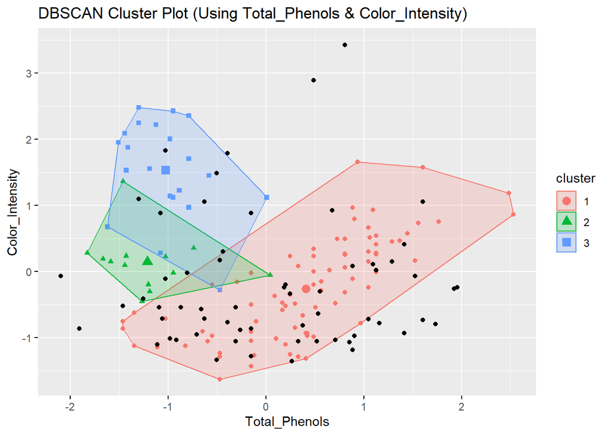

```r
fviz_cluster(db_result, wine_scaled[, c(6, 10)],
             stand = FALSE,
             geom = c("point"),
             ellipse = TRUE) +
  ggtitle("DBSCAN Cluster Plot (Using Total_Phenols & Color_Intensity)")
```

### Interpretation

Red circles = Cluster 1

Green triangles = Cluster 2

Blue squares = Cluster 3

These clusters are formed based on how similar the data points are in Total_Phenols and Color_Intensity.

The black dots represent noise points — these are the observations DBSCAN could not assign to any cluster because they didn’t have enough nearby points within the epsilon radius. This shows DBSCAN’s strength in detecting outliers.

## Reason for visulizing only 2 features

Although DBSCAN clustering was performed using all 13 normalized features, we can only visualize results in 2D or 3D due to human limitations.

In this analysis, we selected Total_Phenols and Color_Intensity to project the clusters onto a 2D plane. These features offer meaningful variation between wine samples and help visualize the structure that DBSCAN discovered.

# Q3 Comparison of K-Means and DBSCAN

## K-Means Clustering

**Pros:**

K-Means works well with big datasets since it is simple to use and computationally quick.

It generates distinct cluster sizes and centroids (e.g., three well-formed clusters of sizes 51, 62, and 65).

In this instance, K-Means produced uniformly spaced clusters that were simple to see and understand.

**Cons:**

We had to specify k = 3 manually, even if it may not reflect the true structure of the data.

All data points were forced into clusters, including those that might be noise or outliers.

Performs poorly when clusters have irregular shapes or varying densities — which limits its flexibility.

## DBSCAN Clustering

**Pros:**

DBSCAN automatically determined the number of clusters (3 clusters + noise) based on density, aligning with the data structure.

Identified 61 noise points, which K-Means forced into clusters.

DBSCAN successfully captured non-spherical, naturally-shaped clusters, especially visible in the plot with ε = 2.1.

**Cons:**

Requires careful tuning of eps and Minimum Points; poor choices can lead to under or over clustering.

Formed one large cluster and two smaller ones (83, 13, 21), which may make interpretation less consistent.

If cluster densities are uneven, DBSCAN may mis-classify points or merge/split clusters incorrectly.

### Conclusion

K-Means works better for dense, spherical, and similarly sized clusters.

DBSCAN works better for non-spherical clusters, noise, and noisy real-world data not suitable for K-Means assumptions.

In this assignment, DBSCAN provided a more flexible and realistic clustering, while K-Means offered simplicity and balanced groupings.